# Calculation of basic and effective reproduction numbers

Andrew Tredennick

2019-02-19

```r
library(tidyverse)
library(pomp)
knitr::opts_chunk$set(message=FALSE, warning=FALSE, cache = FALSE)
source("../../code/make-pomp-simulator-function.R")
```

# Motivation

I want to document, once and for all, how we are calculating the effective reproduction number ($R_E$) for the model fitting `pomp` model and the model simulating `pomp` model. Both models are *SEIR*, but the simulating model includes demography to maintain a constant equilibrium population size, whereas the fitting model includes known population size and more limitted demography (i.e., no deaths).

### Fitting model

The fitting model does not explicitly model the recovered class because we have known population size. Therefore, we only model unvaccinated births into the susceptible class and do not model deaths from any class. We calculate $R_E$ at time *t* as:

$$R_E(t) = \frac{\beta_t}{\gamma} \times \frac{S_t}{N_t},$$
where $\beta_t$ is tranmission rate at time *t*, $1/\gamma$ is the constant recovery period, $S_t$ is the number of susceptibles at time *t*, and $N_t$ is the total population size (known) at time *t*.

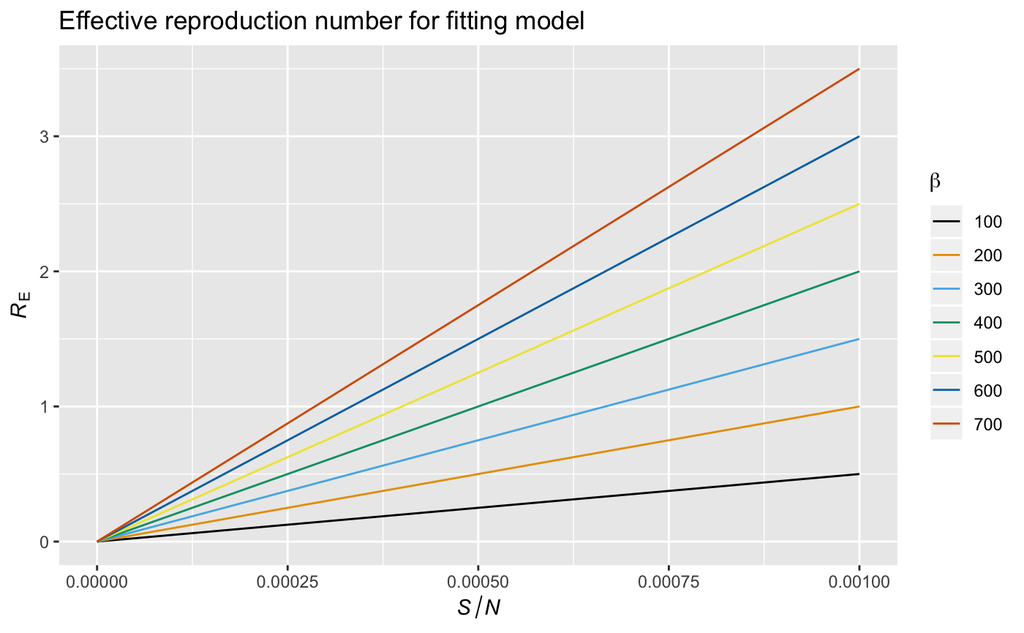

```r
get_re <- function(beta, gamma = (1/5), s_over_n){
  (beta/gamma) * (s_over_n)
}
beta <- seq(100, 700, by = 100)
s_over_n <- seq(0, 0.001, length.out = 20)
res <- tibble()
for(do_beta in beta){
  for(do_frac in s_over_n){
    tmp <- get_re(beta = do_beta, s_over_n = do_frac)
    res %>%
      bind_rows(tibble(
        beta = do_beta,
        s_over_n = do_frac,
        re = tmp
      )) -> res
  }
}
ggplot(res, aes(x = s_over_n, y = re, color = as.factor(beta))) +
  geom_line() +
  labs(x = expression(italic(S/N)), y = expression(italic(R)[E])) +
  ggthemes::scale_color_colorblind(name = expression(beta)) +
  ggtitle("Effective reproduction number for fitting model")
```

### Simulating model

The simulating model includes vaccinated births in the recovered class and deaths from all *SEIR* compartments. We set the birth rate ($\mu$) to equal the death rate ($\nu$; $\mu = \nu = 0.05$) to maintain a relatively constant population size (births and deaths are still stochastic, which is why population size will still vary). Following an online doc ([here](https://web.stanford.edu/~jhj1/teachingdocs/Jones-on-R0.pdf)), we calculate $R_0$ as:

$$R_0 = \frac{\eta \beta}{ (\eta + \nu)(\gamma + \nu)}$$

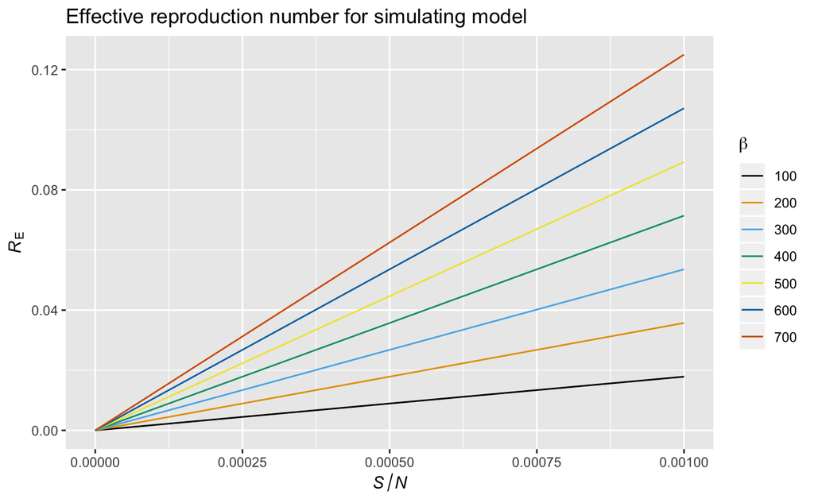

```r
get_re_sim <- function(beta, eta = 1/8, mu = 0.05, nu = 0.05,
                       gamma = 1/5, s_over_n){
  ((eta*beta) / (eta+nu)*(gamma+nu)) * s_over_n
}
beta <- seq(100, 700, by = 100)
s_over_n <- seq(0, 0.001, length.out = 20)
res <- tibble()
for(do_beta in beta){
  for(do_frac in s_over_n){
    tmp <- get_re_sim(beta = do_beta, s_over_n = do_frac)
    res %>%
      bind_rows(tibble(
        beta = do_beta,
        s_over_n = do_frac,
        re = tmp
      )) -> res
  }
}
ggplot(res, aes(x = s_over_n, y = re, color = as.factor(beta))) +
  geom_line() +
  labs(x = expression(italic(S/N)), y = expression(italic(R)[E])) +
  ggthemes::scale_color_colorblind(name = expression(beta)) +
  ggtitle("Effective reproduction number for simulating model")
```